# Data Translation Assignment Question 3

Elias Kazemi and Ryan Ogi

3/13/2022

# 1 Data Cleaning for Question 3 - Who is Earning Money and How has COVID Affected Them?

In this section, we are trying to answer the question: Retail needs to worry about who has money to spend - what has changed about who is working and earning money?

## 1.1 Libraries

```r
library(ipumsr)
library(vtable)
library(tidyverse)
library(lubridate)
library(jtools)
library(haven)
library(rdrobust)
```

## 1.2 Cleaning the EARNWEEK variable

In our EARNWEEK column, 9999.99 is used instead of N/A or blanks in our data for people with unreported data. We must first clean our data to where these 9999.99 values doesn’t affect our models.

```r
df <- read.csv('Rough_DF.csv', header = TRUE)
df <- df %>%
  mutate(EARNWEEK = ifelse(EARNWEEK > 9999, NA_real_, EARNWEEK))
```

Next we must select only the columns that apply to our question. We decided to choose YEAR, MONTH, EMPSTAT, OCC, CLASSWKR, WKSTAT, EARNWEEK, and indname as our variables.

```r
earnweekdf <- df %>%
  select(c(YEAR, MONTH, EMPSTAT, OCC, CLASSWKR, WKSTAT, EARNWEEK, indname))
```

We want to have our dates in “year-month-day” format instead of three separate columns. We want to combine these columns into the “year-month-day” format for analysis later.

```r
earnweekdf$Date <- paste(earnweekdf$MONTH, earnweekdf$YEAR)
earnweekdf$Date <- my(earnweekdf$Date)

earnweekdf <- earnweekdf %>%
  select(-c(YEAR, MONTH))
```

Since we’re measuring the effect of COVID on our the rest of the retail sector as well as the economy, we must add a cutoff date to mark the start of the recession. 2020/01/31 marks as our cutoff date for the start of the recession. Any date after 2020/01/31 will be categorized as “PostCOVID”. This was around the period COVID was labeled a global pandemic.

```r
earnweekdf <- earnweekdf %>%
  mutate(PostCOVID = Date > ymd(20200131))
```

To make our testing data we want to match the industry names with their “PostCOVID” results and their results after the recession date respectively. We then average the earning of each industry with their appropriate results (before COVID date cutoff and after the COVID date cutoff).

```r
effectonearnings <- earnweekdf %>%
  group_by(indname, PostCOVID) %>%
  summarize(avgearn = mean(EARNWEEK, na.rm = TRUE))
```

## 1.3 Quick Look

Our code below shows, removed any missing values in the data set, filtering in the pre COVID results, finding the mean of our pre-COVID earning average, filtering in the post COVID results, and finding the mean of our post COVID earning average.

TRUE shows the average earnings post cutoff COVID date. FALSE shows the average earnings pre cutoff COVID date.

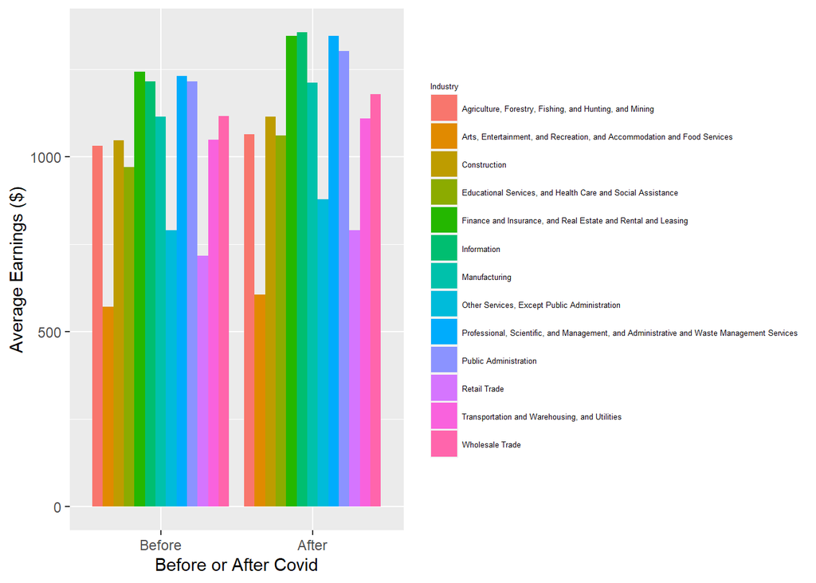

```r
effectonearnings <- effectonearnings %>%
  drop_na()

PostCOVIDearnavg <- effectonearnings %>%
  filter(PostCOVID == TRUE)

PostCOVIDearnavg <- mean(PostCOVIDearnavg$avgearn)

postcovidearnavg <- effectonearnings %>%
  filter(PostCOVID == FALSE)

postcovidearnavg <- mean(postcovidearnavg$avgearn)

ggplot(data = effectonearnings, aes(x = PostCOVID, y = avgearn, fill = indname)) + geom_bar(stat = "identity", position = position_dodge()) + theme(legend.title = element_text(size = 5), legend.text = element_text(size = 5)) + guides(color = guide_legend(override.aes = list(size = 0.5))) + guides(shape = guide_legend(override.aes = list(size = 0.5))) + labs(x = 'Before or After Covid', y = 'Average Earnings ($)', fill = 'Industry') + scale_x_discrete(labels=c("FALSE" = "Before", "TRUE" = "After"))
```

## 1.4 Quick Comments

# 2 Regression Discontinuity Analaysis (RDD) - Earnings over Time

## 2.1 How has Earnings Changed and How has COVID Affected Them?

We’re testing to see the difference in earning per week before and after the COVID cutoff date. Our group decided to find the regression for earning per week for each industry in respect to before and after the cutoff COVID date (2020/01/31). The first graph shows the industry earning per week in respect to the year (macro, long-term). The second graph shows a zoomed in focus on earnings per week closer towards the cutoff COVID date (micro, immediate affect).

*We will really only be doing analysis for the retail industry and other industries that have a statistically significant effect.*

### 2.1.1 Retail Industry

```r
earnweekdf1 <- earnweekdf %>%
  filter(indname == 'Retail Trade')

m1 <- lm(EARNWEEK ~ Date * PostCOVID, data = earnweekdf1)
export_summs(m1)
```

|  | Model 1 |
| --- | --- |
| (Intercept) | -863.40 *** |
|  | (255.85) |
| Date | 0.09 *** |
|  | (0.01) |
| PostCOVIDTRUE | -394.01 |
|  | (398.54) |
| Date:PostCOVIDTRUE | 0.02 |
|  | (0.02) |
| N | 69572 |
| R2 | 0.00 |
| *** p < 0.001; ** p < 0.01; * p < 0.05. |  |

However, this interaction is not statistically significant, so this association of COVID on earnings is not one that we can say is strong enough to reject the null hypothesis that there was no effect on earnings for this industry.

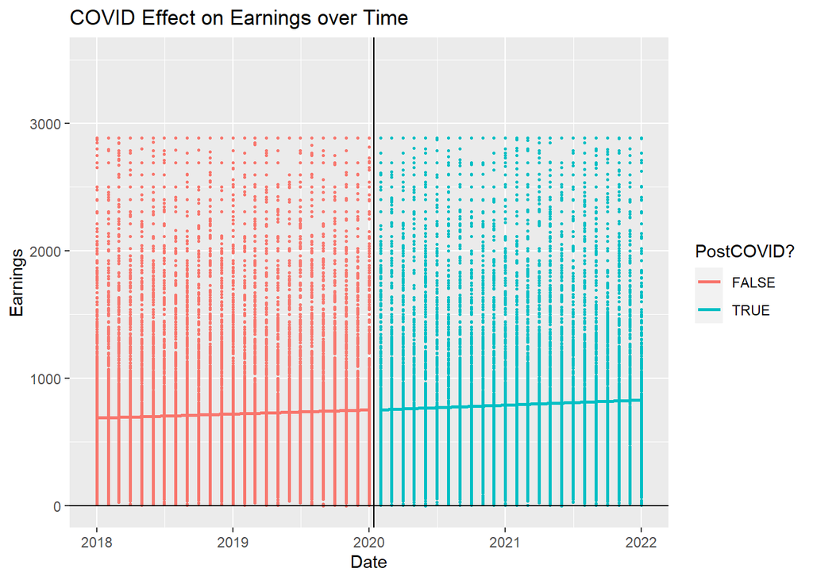

```r
earnweekdf1 %>% mutate(date_group = as.factor(PostCOVID)) %>% ggplot(aes(x = Date, y = EARNWEEK, color = date_group)) + geom_point(size = 0.5) + geom_vline(xintercept = mdy(01152020)) + geom_smooth(method = "lm", se = FALSE) + ylim(0,3500) + geom_hline(yintercept = 0) + labs(title = 'COVID Effect on Earnings over Time', y = 'Earnings', color = 'PostCOVID?')
```

This graph shoes us this similar relationship. The line is the average of the values on each day. For the retail, the effect is very minimal, if existent at all (considering the results were not statistically significant)

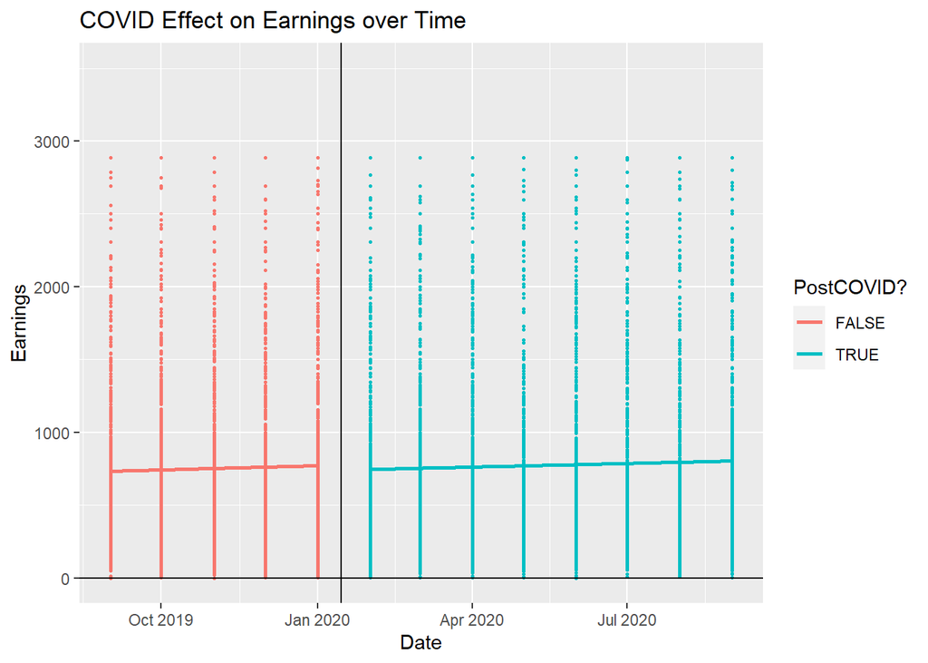

```r
earnweekdf1 %>% mutate(date_group = as.factor(PostCOVID)) %>% ggplot(aes(x = Date, y = EARNWEEK, color = date_group)) + geom_point(size = 0.5) + geom_vline(xintercept = mdy(01152020)) + geom_smooth(method = "lm", se = FALSE) + ylim(0,3500) + geom_hline(yintercept = 0) + xlim(mdy(09012019),mdy(09012020)) + labs(title = 'COVID Effect on Earnings over Time', y = 'Earnings', color = 'PostCOVID?')
```

By taking a closer look, we can see that the average retail employee’s weekly earnings did not really change much when COVID was declared a national pandemic. So, as we go through the rest of the industries, we will only be analyzing ones that have statistically significant results.

### 2.1.2 Professional, Scientific, Management, and Administrative and Waste Management Services Industry

Professional, Scientific, and Management, and Administrative and Waste Management Services benefited since the COVID cutoff date. An increase in earnings per week was shown immediately and continues to increase in the future.

```r
earnweekdf2 <- earnweekdf %>%
  filter(indname == 'Professional, Scientific, and Management, and Administrative and Waste Management Services')

m2 <- lm(EARNWEEK ~ Date * PostCOVID, data = earnweekdf2)
export_summs(m2)
```

|  | Model 1 |
| --- | --- |
| (Intercept) | -1567.27 *** |
|  | (343.63) |
| Date | 0.16 *** |
|  | (0.02) |
| PostCOVIDTRUE | 1657.70 ** |
|  | (528.43) |
| Date:PostCOVIDTRUE | -0.09 ** |
|  | (0.03) |
| N | 69465 |
| R2 | 0.01 |
| *** p < 0.001; ** p < 0.01; * p < 0.05. |  |

In this model, we can see a statistically significant effect of COVID on earnings for the Professional, Scientific, Management, and Administrative and Waste Management Services industry. Our interaction shows a 0.09 decrease in the slope after COVID, so although earnings increased over the course of a few years, it increased at a much slower rate for this industry.

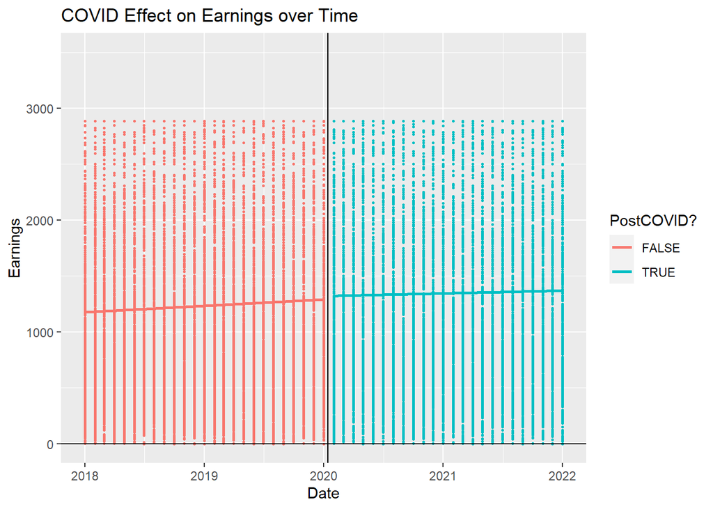

```r
earnweekdf2 %>% mutate(date_group = as.factor(PostCOVID)) %>% ggplot(aes(x = Date, y = EARNWEEK, color = date_group)) + geom_point(size = 0.5) + geom_vline(xintercept = mdy(01152020)) + geom_smooth(method = "lm", se = FALSE) + ylim(0,3500) + geom_hline(yintercept = 0) + labs(title = 'COVID Effect on Earnings over Time', y = 'Earnings', color = 'PostCOVID?')
```

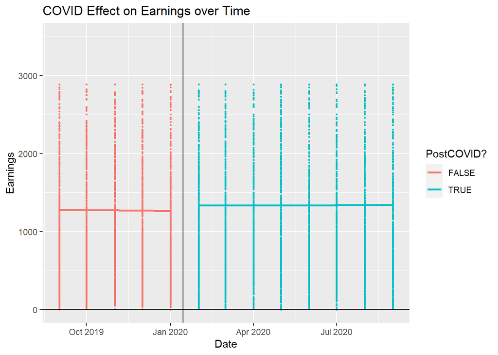

```r
earnweekdf2 %>% mutate(date_group = as.factor(PostCOVID)) %>% ggplot(aes(x = Date, y = EARNWEEK, color = date_group)) + geom_point(size = 0.5) + geom_vline(xintercept = mdy(01152020)) + geom_smooth(method = "lm", se = FALSE) + ylim(0,3500) + geom_hline(yintercept = 0) + xlim(mdy(09012019),mdy(09012020)) + labs(title = 'COVID Effect on Earnings over Time', y = 'Earnings', color = 'PostCOVID?')
```

### 2.1.3 Finance and Insurance, and Real Estate and Rental and Leasing Industry

```r
earnweekdf3 <- earnweekdf %>%
  filter(indname == 'Finance and Insurance, and Real Estate and Rental and Leasing')

m3 <- lm(EARNWEEK ~ Date * PostCOVID, data = earnweekdf3)
export_summs(m3)
```

|  | Model 1 |
| --- | --- |
| (Intercept) | -1091.50 ** |
|  | (423.30) |
| Date | 0.13 *** |
|  | (0.02) |
| PostCOVIDTRUE | -25.84 |
|  | (650.79) |
| Date:PostCOVIDTRUE | 0.00 |
|  | (0.04) |
| N | 42356 |
| R2 | 0.01 |
| *** p < 0.001; ** p < 0.01; * p < 0.05. |  |

Here we have basically no effect of COVID on employee weekly earnings. However, this isn’t statistically significant, so there may have been one, but the model did not see one.

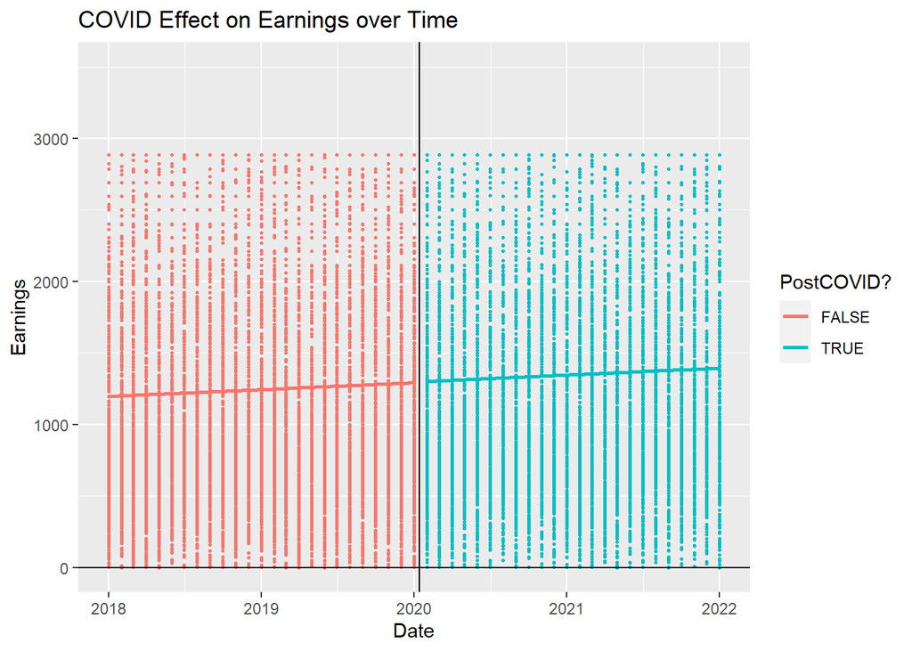

```r
earnweekdf3 %>% mutate(date_group = as.factor(PostCOVID)) %>% ggplot(aes(x = Date, y = EARNWEEK, color = date_group)) + geom_point(size = 0.5) + geom_vline(xintercept = mdy(01152020)) + geom_smooth(method = "lm", se = FALSE) + ylim(0,3500) + geom_hline(yintercept = 0) + labs(title = 'COVID Effect on Earnings over Time', y = 'Earnings', color = 'PostCOVID?')
```

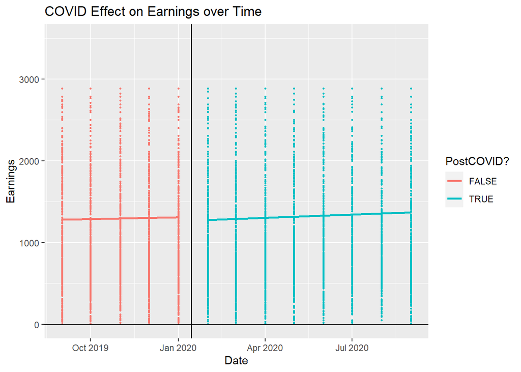

```r
earnweekdf3 %>% mutate(date_group = as.factor(PostCOVID)) %>% ggplot(aes(x = Date, y = EARNWEEK, color = date_group)) + geom_point(size = 0.5) + geom_vline(xintercept = mdy(01152020)) + geom_smooth(method = "lm", se = FALSE) + ylim(0,3500) + geom_hline(yintercept = 0) + xlim(mdy(09012019),mdy(09012020)) + labs(title = 'COVID Effect on Earnings over Time', y = 'Earnings', color = 'PostCOVID?')
```

### 2.1.4 Educational Services, and Health Care and Social Assistance Industry

```r
earnweekdf4 <- earnweekdf %>%
  filter(indname == 'Educational Services, and Health Care and Social Assistance')

m4 <- lm(EARNWEEK ~ Date * PostCOVID, data = earnweekdf4)
export_summs(m4)
```

|  | Model 1 |
| --- | --- |
| (Intercept) | -640.16 *** |
|  | (186.51) |
| Date | 0.09 *** |
|  | (0.01) |
| PostCOVIDTRUE | -278.78 |
|  | (289.76) |
| Date:PostCOVIDTRUE | 0.02 |
|  | (0.02) |
| N | 159592 |
| R2 | 0.01 |
| *** p < 0.001; ** p < 0.01; * p < 0.05. |  |

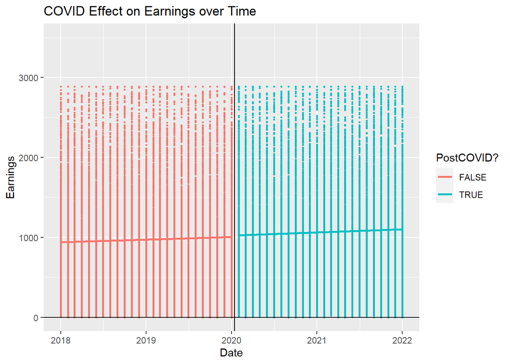

```r
earnweekdf4 %>% mutate(date_group = as.factor(PostCOVID)) %>% ggplot(aes(x = Date, y = EARNWEEK, color = date_group)) + geom_point(size = 0.5) + geom_vline(xintercept = mdy(01152020)) + geom_smooth(method = "lm", se = FALSE) + ylim(0,3500) + geom_hline(yintercept = 0) + labs(title = 'COVID Effect on Earnings over Time', y = 'Earnings', color = 'PostCOVID?')
```

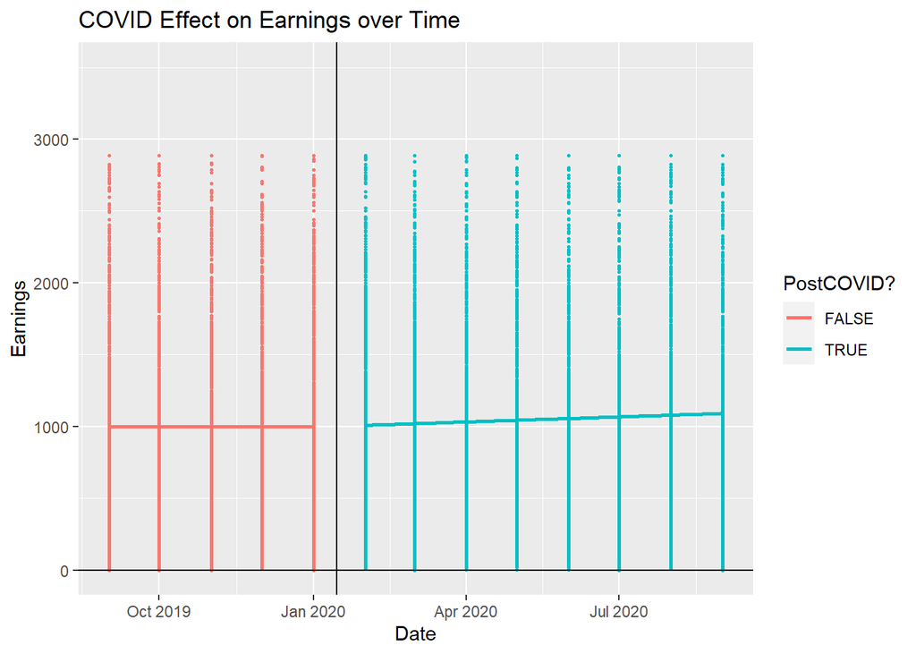

```r
earnweekdf4 %>% mutate(date_group = as.factor(PostCOVID)) %>% ggplot(aes(x = Date, y = EARNWEEK, color = date_group)) + geom_point(size = 0.5) + geom_vline(xintercept = mdy(01152020)) + geom_smooth(method = "lm", se = FALSE) + ylim(0,3500) + geom_hline(yintercept = 0) + xlim(mdy(09012019),mdy(09012020)) + labs(title = 'COVID Effect on Earnings over Time', y = 'Earnings', color = 'PostCOVID?')
```

### 2.1.5 Arts, Entertainment, and Recreation, and Accommodation and Food Services Industry

```r
earnweekdf5 <- earnweekdf %>%
  filter(indname == 'Arts, Entertainment, and Recreation, and Accommodation and Food Services')

m5 <- lm(EARNWEEK ~ Date * PostCOVID, data = earnweekdf5)
export_summs(m5)
```

|  | Model 1 |
| --- | --- |
| (Intercept) | -517.85 * |
|  | (233.88) |
| Date | 0.06 *** |
|  | (0.01) |
| PostCOVIDTRUE | -172.31 |
|  | (376.48) |
| Date:PostCOVIDTRUE | 0.01 |
|  | (0.02) |
| N | 55405 |
| R2 | 0.00 |
| *** p < 0.001; ** p < 0.01; * p < 0.05. |  |

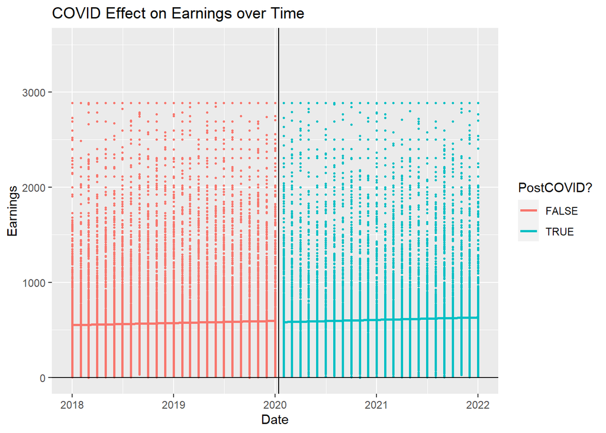

```r
earnweekdf5 %>% mutate(date_group = as.factor(PostCOVID)) %>% ggplot(aes(x = Date, y = EARNWEEK, color = date_group)) + geom_point(size = 0.5) + geom_vline(xintercept = mdy(01152020)) + geom_smooth(method = "lm", se = FALSE) + ylim(0,3500) + geom_hline(yintercept = 0) + labs(title = 'COVID Effect on Earnings over Time', y = 'Earnings', color = 'PostCOVID?')
```

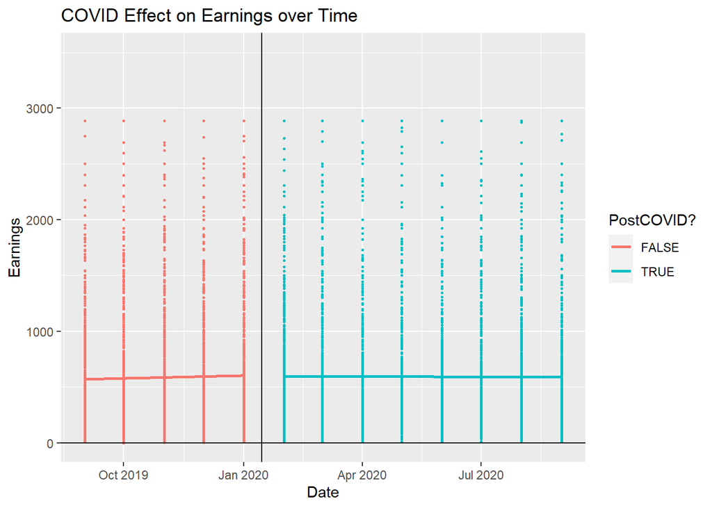

```r
earnweekdf5 %>% mutate(date_group = as.factor(PostCOVID)) %>% ggplot(aes(x = Date, y = EARNWEEK, color = date_group)) + geom_point(size = 0.5) + geom_vline(xintercept = mdy(01152020)) + geom_smooth(method = "lm", se = FALSE) + ylim(0,3500) + geom_hline(yintercept = 0) + xlim(mdy(09012019),mdy(09012020)) + labs(title = 'COVID Effect on Earnings over Time', y = 'Earnings', color = 'PostCOVID?')
```

### 2.1.6 Public Administration Industry

```r
earnweekdf6 <- earnweekdf %>%
  filter(indname == 'Public Administration')

m6 <- lm(EARNWEEK ~ Date * PostCOVID, data = earnweekdf6)
export_summs(m6)
```

|  | Model 1 |
| --- | --- |
| (Intercept) | -388.74 |
|  | (403.65) |
| Date | 0.09 *** |
|  | (0.02) |
| PostCOVIDTRUE | -130.86 |
|  | (615.49) |
| Date:PostCOVIDTRUE | 0.01 |
|  | (0.03) |
| N | 38156 |
| R2 | 0.00 |
| *** p < 0.001; ** p < 0.01; * p < 0.05. |  |

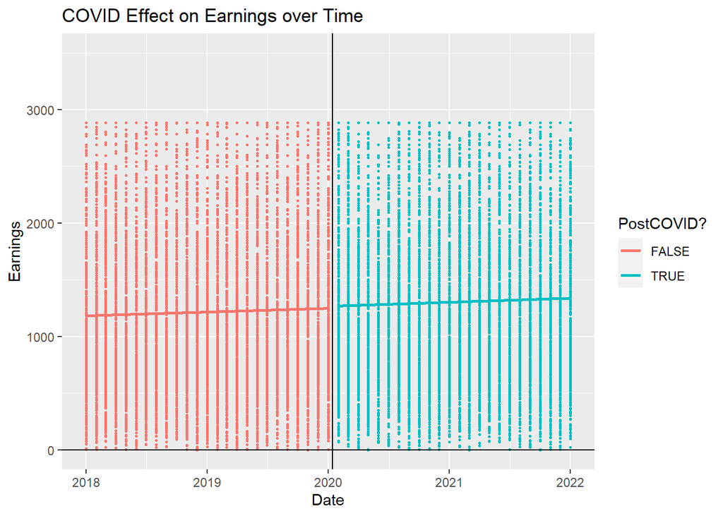

```r
earnweekdf6 %>% mutate(date_group = as.factor(PostCOVID)) %>% ggplot(aes(x = Date, y = EARNWEEK, color = date_group)) + geom_point(size = 0.5) + geom_vline(xintercept = mdy(01152020)) + geom_smooth(method = "lm", se = FALSE) + ylim(0,3500) + geom_hline(yintercept = 0) + labs(title = 'COVID Effect on Earnings over Time', y = 'Earnings', color = 'PostCOVID?')
```

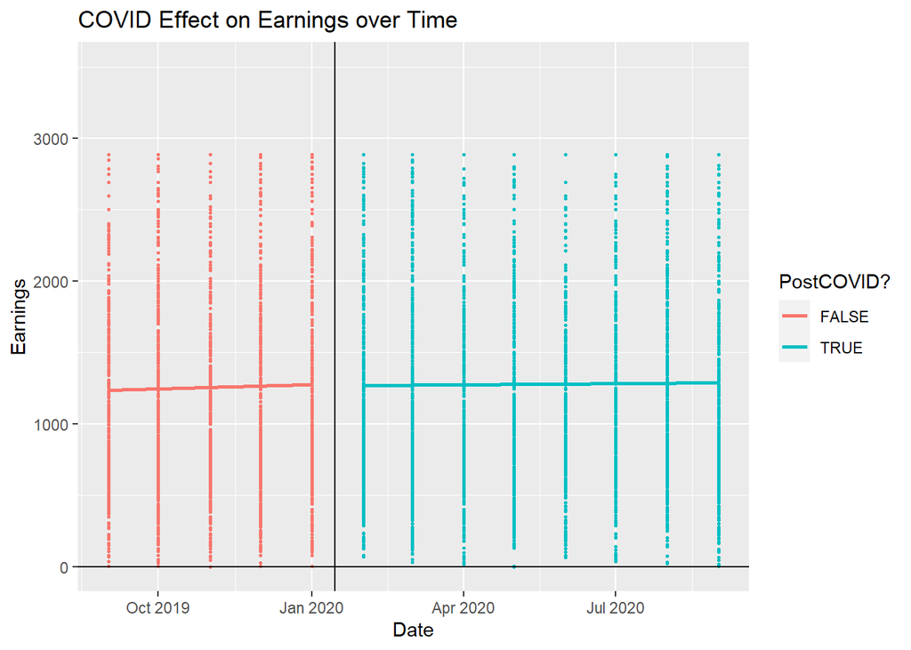

```r
earnweekdf6 %>% mutate(date_group = as.factor(PostCOVID)) %>% ggplot(aes(x = Date, y = EARNWEEK, color = date_group)) + geom_point(size = 0.5) + geom_vline(xintercept = mdy(01152020)) + geom_smooth(method = "lm", se = FALSE) + ylim(0,3500) + geom_hline(yintercept = 0) + xlim(mdy(09012019),mdy(09012020)) + labs(title = 'COVID Effect on Earnings over Time', y = 'Earnings', color = 'PostCOVID?')
```

### 2.1.7 Agriculture, Forestry, Fishing, and Hunting, and Mining Industry

```r
earnweekdf7 <- earnweekdf %>%
  filter(indname == 'Agriculture, Forestry, Fishing, and Hunting, and Mining')

m7 <- lm(EARNWEEK ~ Date * PostCOVID, data = earnweekdf7)
export_summs(m7)
```

|  | Model 1 |
| --- | --- |
| (Intercept) | -1388.28 |
|  | (718.41) |
| Date | 0.14 *** |
|  | (0.04) |
| PostCOVIDTRUE | 2436.46 * |
|  | (1121.85) |
| Date:PostCOVIDTRUE | -0.13 * |
|  | (0.06) |
| N | 11845 |
| R2 | 0.00 |
| *** p < 0.001; ** p < 0.01; * p < 0.05. |  |

Here, we have another statistically significant result at p < 0.05, where COVID has a pretty substantial effect on earnings in the Agriculture, Forestry, Fishing, and Hunting, and Mining industries. COVID basically made the increase in weekly earnings across the years non-existent when it was declared a global pandemic, with earnings only increasing by 0.01 per day post-COVID.

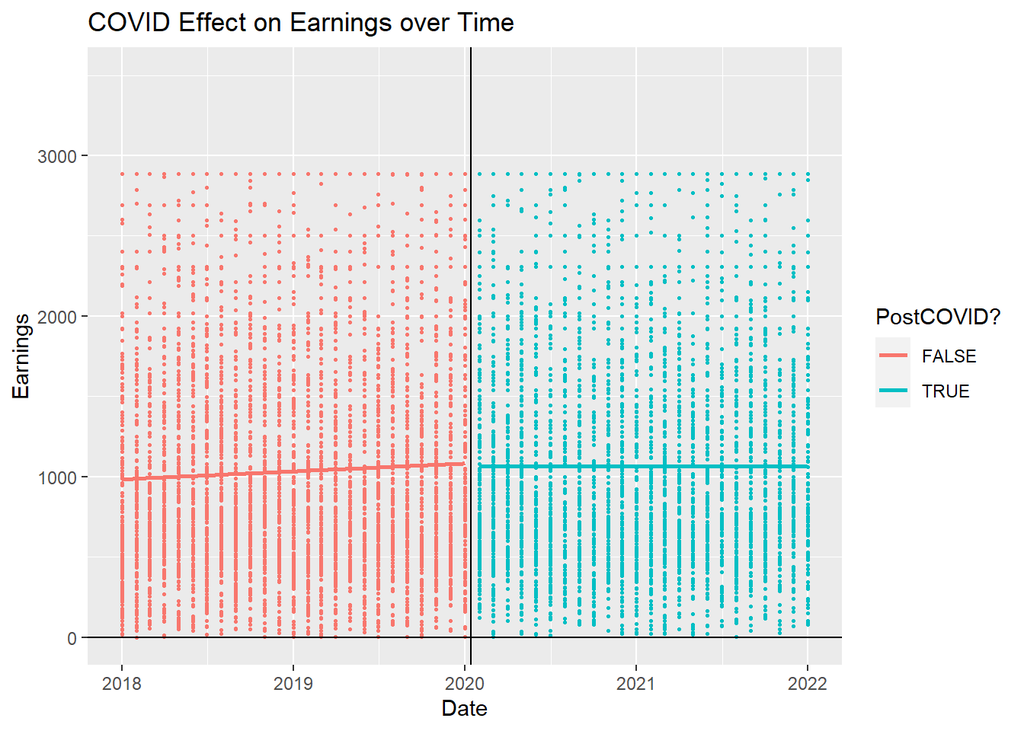

```r
earnweekdf7 %>% mutate(date_group = as.factor(PostCOVID)) %>% ggplot(aes(x = Date, y = EARNWEEK, color = date_group)) + geom_point(size = 0.5) + geom_vline(xintercept = mdy(01152020)) + geom_smooth(method = "lm", se = FALSE) + ylim(0,3500) + geom_hline(yintercept = 0) + labs(title = 'COVID Effect on Earnings over Time', y = 'Earnings', color = 'PostCOVID?')
```

We can see the graph here showing this almost constant weekly earnings after COVID hit.

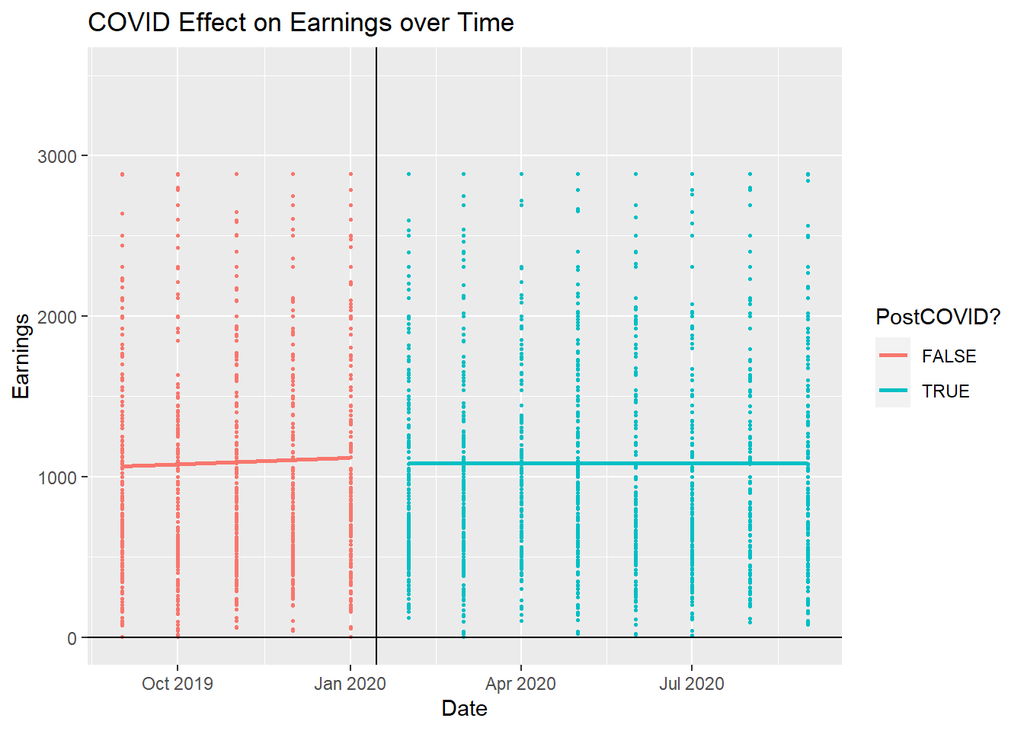

```r
earnweekdf7 %>% mutate(date_group = as.factor(PostCOVID)) %>% ggplot(aes(x = Date, y = EARNWEEK, color = date_group)) + geom_point(size = 0.5) + geom_vline(xintercept = mdy(01152020)) + geom_smooth(method = "lm", se = FALSE) + ylim(0,3500) + geom_hline(yintercept = 0) + xlim(mdy(09012019),mdy(09012020)) + labs(title = 'COVID Effect on Earnings over Time', y = 'Earnings', color = 'PostCOVID?')
```

### 2.1.8 Transportation and Warehousing, and Utilities Industry

```r
earnweekdf8 <- earnweekdf %>%
  filter(indname == 'Transportation and Warehousing, and Utilities')

m8 <- lm(EARNWEEK ~ Date * PostCOVID, data = earnweekdf8)
export_summs(m8)
```

|  | Model 1 |
| --- | --- |
| (Intercept) | 763.58 |
|  | (390.53) |
| Date | 0.02 |
|  | (0.02) |
| PostCOVIDTRUE | 100.12 |
|  | (593.35) |
| Date:PostCOVIDTRUE | -0.00 |
|  | (0.03) |
| N | 35835 |
| R2 | 0.00 |
| *** p < 0.001; ** p < 0.01; * p < 0.05. |  |

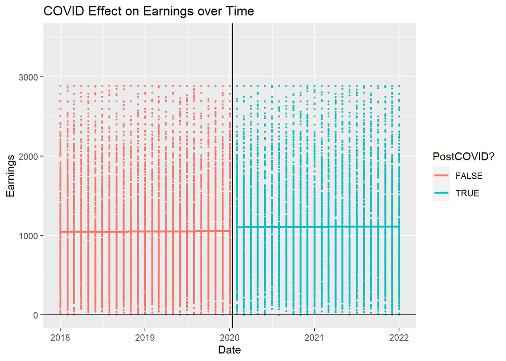

```r
earnweekdf8 %>% mutate(date_group = as.factor(PostCOVID)) %>% ggplot(aes(x = Date, y = EARNWEEK, color = date_group)) + geom_point(size = 0.5) + geom_vline(xintercept = mdy(01152020)) + geom_smooth(method = "lm", se = FALSE) + ylim(0,3500) + geom_hline(yintercept = 0) + labs(title = 'COVID Effect on Earnings over Time', y = 'Earnings', color = 'PostCOVID?')
```

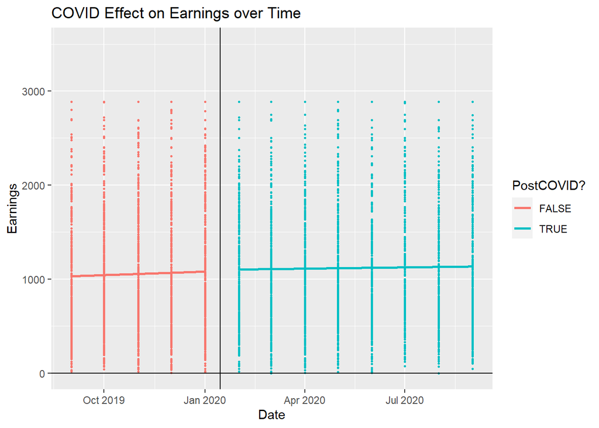

```r
earnweekdf8 %>% mutate(date_group = as.factor(PostCOVID)) %>% ggplot(aes(x = Date, y = EARNWEEK, color = date_group)) + geom_point(size = 0.5) + geom_vline(xintercept = mdy(01152020)) + geom_smooth(method = "lm", se = FALSE) + ylim(0,3500) + geom_hline(yintercept = 0) + xlim(mdy(09012019),mdy(09012020)) + labs(title = 'COVID Effect on Earnings over Time', y = 'Earnings', color = 'PostCOVID?')
```

### 2.1.9 Construction Industry

```r
earnweekdf9 <- earnweekdf %>%
  filter(indname == 'Construction')

m9 <- lm(EARNWEEK ~ Date * PostCOVID, data = earnweekdf9)
export_summs(m9)
```

|  | Model 1 |
| --- | --- |
| (Intercept) | -674.81 |
|  | (351.26) |
| Date | 0.10 *** |
|  | (0.02) |
| PostCOVIDTRUE | 1074.70 * |
|  | (546.14) |
| Date:PostCOVIDTRUE | -0.06 |
|  | (0.03) |
| N | 38684 |
| R2 | 0.00 |
| *** p < 0.001; ** p < 0.01; * p < 0.05. |  |

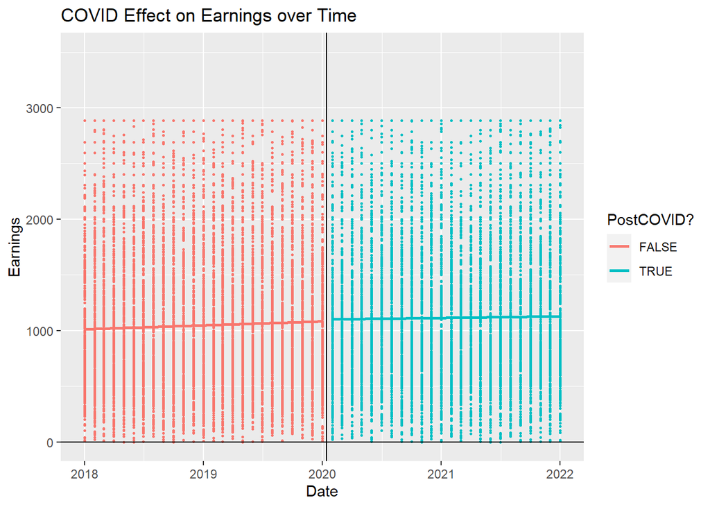

```r
earnweekdf9 %>% mutate(date_group = as.factor(PostCOVID)) %>% ggplot(aes(x = Date, y = EARNWEEK, color = date_group)) + geom_point(size = 0.5) + geom_vline(xintercept = mdy(01152020)) + geom_smooth(method = "lm", se = FALSE) + ylim(0,3500) + geom_hline(yintercept = 0) + labs(title = 'COVID Effect on Earnings over Time', y = 'Earnings', color = 'PostCOVID?')
```

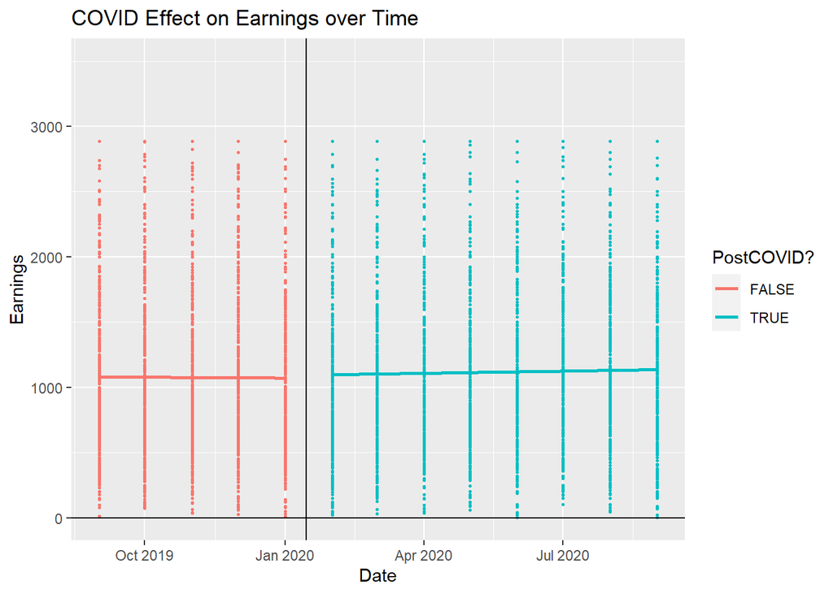

```r
earnweekdf9 %>% mutate(date_group = as.factor(PostCOVID)) %>% ggplot(aes(x = Date, y = EARNWEEK, color = date_group)) + geom_point(size = 0.5) + geom_vline(xintercept = mdy(01152020)) + geom_smooth(method = "lm", se = FALSE) + ylim(0,3500) + geom_hline(yintercept = 0) + xlim(mdy(09012019),mdy(09012020)) + labs(title = 'COVID Effect on Earnings over Time', y = 'Earnings', color = 'PostCOVID?')
```

### 2.1.10 Manufacturing Industry

Manufacturing Industry benefited since the COVID cutoff date. An increase in earnings per week was shown immediately and continues to increase in the future.

```r
earnweekdf10 <- earnweekdf %>%
  filter(indname == 'Manufacturing')

m10 <- lm(EARNWEEK ~ Date * PostCOVID, data = earnweekdf10)
export_summs(m10)
```

|  | Model 1 |
| --- | --- |
| (Intercept) | -43.68 |
|  | (299.84) |
| Date | 0.06 *** |
|  | (0.02) |
| PostCOVIDTRUE | 243.61 |
|  | (466.64) |
| Date:PostCOVIDTRUE | -0.01 |
|  | (0.03) |
| N | 66506 |
| R2 | 0.01 |
| *** p < 0.001; ** p < 0.01; * p < 0.05. |  |

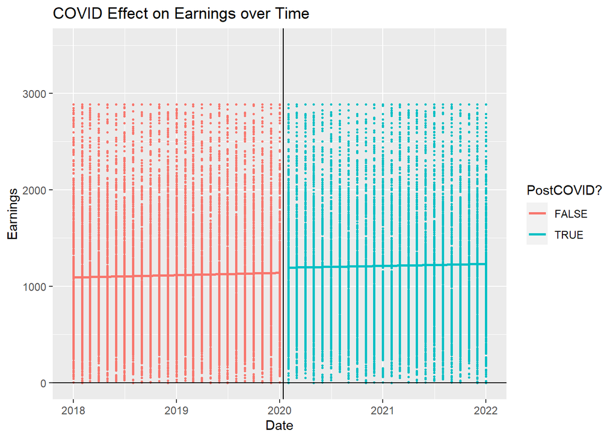

```r
earnweekdf10 %>% mutate(date_group = as.factor(PostCOVID)) %>% ggplot(aes(x = Date, y = EARNWEEK, color = date_group)) + geom_point(size = 0.5) + geom_vline(xintercept = mdy(01152020)) + geom_smooth(method = "lm", se = FALSE) + ylim(0,3500) + geom_hline(yintercept = 0) + labs(title = 'COVID Effect on Earnings over Time', y = 'Earnings', color = 'PostCOVID?')
```

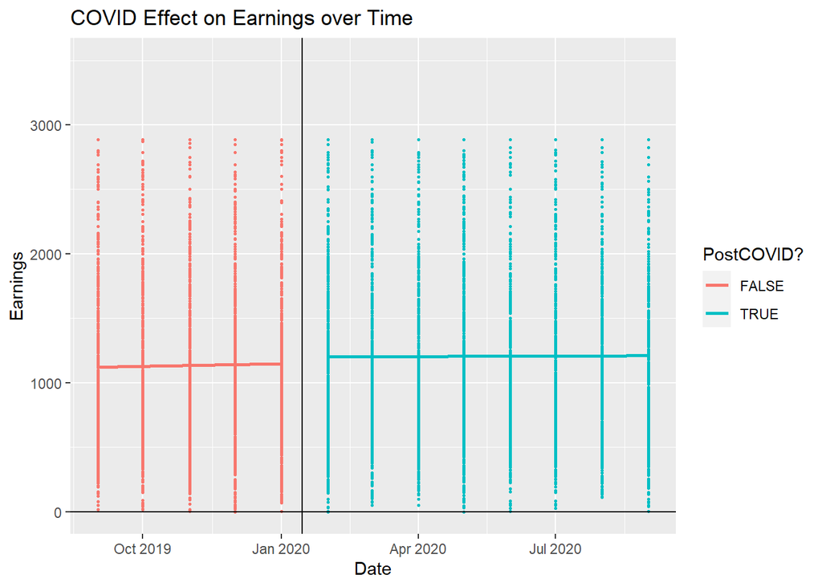

```r
earnweekdf10 %>% mutate(date_group = as.factor(PostCOVID)) %>% ggplot(aes(x = Date, y = EARNWEEK, color = date_group)) + geom_point(size = 0.5) + geom_vline(xintercept = mdy(01152020)) + geom_smooth(method = "lm", se = FALSE) + ylim(0,3500) + geom_hline(yintercept = 0) + xlim(mdy(09012019),mdy(09012020)) + labs(title = 'COVID Effect on Earnings over Time', y = 'Earnings', color = 'PostCOVID?')
```

### 2.1.11 Other Services, Except Public Administration Industry

Initially, Other Services, Except Public Administration Industry had a decease in earnings per week. A few months after the COVID cutoff, Other Services, Except Public Administration Industry were able to stabilize. In later years, Other Services, Except Public Administration Industry were able to have a growth in earnings per week.

```r
earnweekdf10 <- earnweekdf %>%
  filter(indname == 'Other Services, Except Public Administration')

m10 <- lm(EARNWEEK ~ Date * PostCOVID, data = earnweekdf10)
export_summs(m10)
```

|  | Model 1 |
| --- | --- |
| (Intercept) | -892.21 * |
|  | (416.86) |
| Date | 0.09 *** |
|  | (0.02) |
| PostCOVIDTRUE | 186.33 |
|  | (653.85) |
| Date:PostCOVIDTRUE | -0.01 |
|  | (0.04) |
| N | 27685 |
| R2 | 0.01 |
| *** p < 0.001; ** p < 0.01; * p < 0.05. |  |

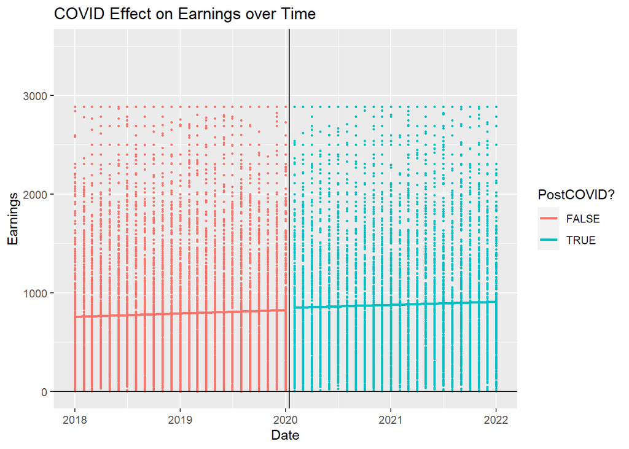

```r
earnweekdf10 %>% mutate(date_group = as.factor(PostCOVID)) %>% ggplot(aes(x = Date, y = EARNWEEK, color = date_group)) + geom_point(size = 0.5) + geom_vline(xintercept = mdy(01152020)) + geom_smooth(method = "lm", se = FALSE) + ylim(0,3500) + geom_hline(yintercept = 0) + labs(title = 'COVID Effect on Earnings over Time', y = 'Earnings', color = 'PostCOVID?')
```

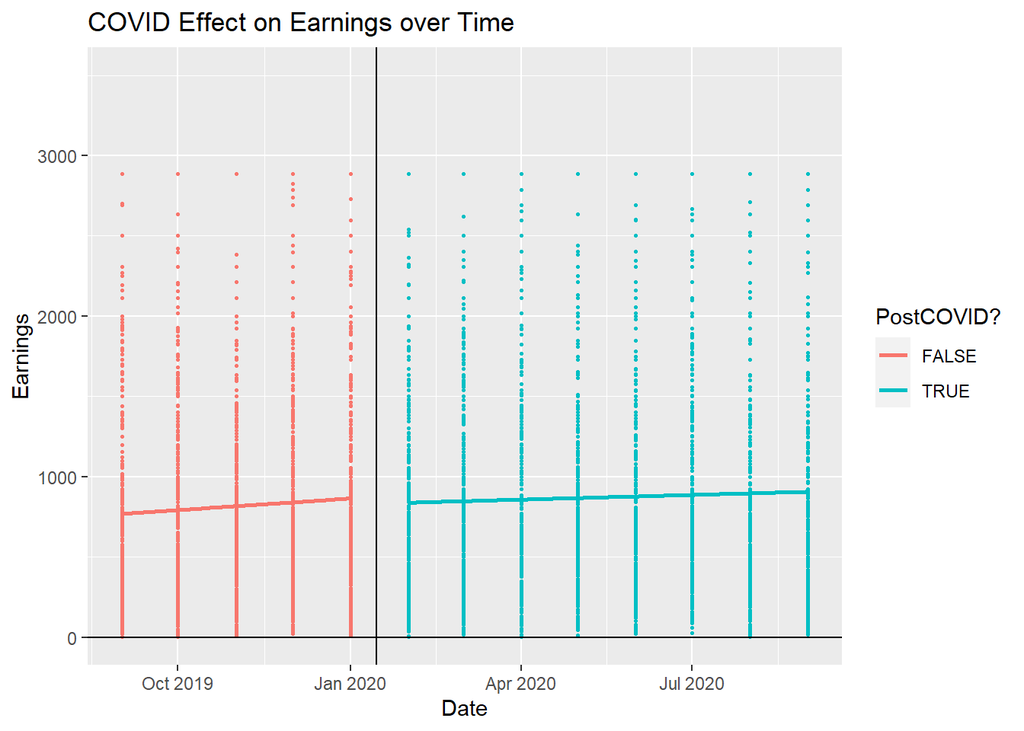

```r
earnweekdf10 %>% mutate(date_group = as.factor(PostCOVID)) %>% ggplot(aes(x = Date, y = EARNWEEK, color = date_group)) + geom_point(size = 0.5) + geom_vline(xintercept = mdy(01152020)) + geom_smooth(method = "lm", se = FALSE) + ylim(0,3500) + geom_hline(yintercept = 0) + xlim(mdy(09012019),mdy(09012020)) + labs(title = 'COVID Effect on Earnings over Time', y = 'Earnings', color = 'PostCOVID?')
```